# AirBnB Dataset - Exploratory Data Analysis

his’R’ustu

8/30/2020

## Introduction

See the description taken from Kaggle page.

### Context

Since 2008, guests and hosts have used Airbnb to expand on traveling possibilities and present more unique, personalized way of experiencing the world. This dataset describes the listing activity and metrics in NYC, NY for 2019.

### Content

This data file includes all needed information to find out more about hosts, geographical availability, necessary metrics to make predictions and draw conclusions.

### Acknowledgements

This public dataset is part of Airbnb, and the original source can be found on this [website](http://insideairbnb.com/).

### Libraries and Dataset

```r
library(dplyr)
library(ggplot2)
library(lubridate)
library(tidyr)
library(data.table)

data <- readRDS("data/AB_NYC_2019.rds")
```

## Summary of The Dataset

There are nearly 49K rows and 16 columns. Data types seem correct expect last_review column. It’s necessary to convert last_review to date format.

```r
glimpse(data)
```

```
## Rows: 48,895
## Columns: 16
## $ id                             <int> 2539, 2595, 3647, 3831, 5022, 5099, 51…
## $ name                           <chr> "Clean & quiet apt home by the park", …
## $ host_id                        <int> 2787, 2845, 4632, 4869, 7192, 7322, 73…
## $ host_name                      <chr> "John", "Jennifer", "Elisabeth", "Lisa…
## $ neighbourhood_group            <chr> "Brooklyn", "Manhattan", "Manhattan", …
## $ neighbourhood                  <chr> "Kensington", "Midtown", "Harlem", "Cl…
## $ latitude                       <dbl> 40.64749, 40.75362, 40.80902, 40.68514…
## $ longitude                      <dbl> -73.97237, -73.98377, -73.94190, -73.9…
## $ room_type                      <chr> "Private room", "Entire home/apt", "Pr…
## $ price                          <int> 149, 225, 150, 89, 80, 200, 60, 79, 79…
## $ minimum_nights                 <int> 1, 1, 3, 1, 10, 3, 45, 2, 2, 1, 5, 2, …
## $ number_of_reviews              <int> 9, 45, 0, 270, 9, 74, 49, 430, 118, 16…
## $ last_review                    <chr> "2018-10-19", "2019-05-21", "", "2019-…
## $ reviews_per_month              <dbl> 0.21, 0.38, NA, 4.64, 0.10, 0.59, 0.40…
## $ calculated_host_listings_count <int> 6, 2, 1, 1, 1, 1, 1, 1, 1, 4, 1, 1, 3,…
## $ availability_365               <int> 365, 355, 365, 194, 0, 129, 0, 220, 0,…
```

```r
data$last_review <- as.Date(parse_date_time(data$last_review, c('ymd')))
```

```r
na_count <-sapply(data, function(y) sum(length(which(is.na(y)))))
na_count <- data.frame(na_count)
na_count
```

```
##                                na_count
## id                                    0
## name                                  0
## host_id                               0
## host_name                             0
## neighbourhood_group                   0
## neighbourhood                         0
## latitude                              0
## longitude                             0
## room_type                             0
## price                                 0
## minimum_nights                        0
## number_of_reviews                     0
## last_review                       10052
## reviews_per_month                 10052
## calculated_host_listings_count        0
## availability_365                      0
```

Let’s select important columns and see some of the rows as sample.

```r
selected <- select(data, neighbourhood_group, neighbourhood, room_type, price, minimum_nights, number_of_reviews, last_review, reviews_per_month, calculated_host_listings_count, availability_365)
head(selected)
```

```
##   neighbourhood_group neighbourhood       room_type price minimum_nights
## 1            Brooklyn    Kensington    Private room   149              1
## 2           Manhattan       Midtown Entire home/apt   225              1
## 3           Manhattan        Harlem    Private room   150              3
## 4            Brooklyn  Clinton Hill Entire home/apt    89              1
## 5           Manhattan   East Harlem Entire home/apt    80             10
## 6           Manhattan   Murray Hill Entire home/apt   200              3
##   number_of_reviews last_review reviews_per_month
## 1                 9  2018-10-19              0.21
## 2                45  2019-05-21              0.38
## 3                 0        <NA>                NA
## 4               270  2019-07-05              4.64
## 5                 9  2018-11-19              0.10
## 6                74  2019-06-22              0.59
##   calculated_host_listings_count availability_365
## 1                              6              365
## 2                              2              355
## 3                              1              365
## 4                              1              194
## 5                              1                0
## 6                              1              129
```

There are 3 different room types. One can book a private room or share the room and also one can book an entire place.

```r
print(c(c(unique(selected["neighbourhood_group"])),c(unique(selected["room_type"]))))
```

```
## $neighbourhood_group
## [1] "Brooklyn"      "Manhattan"     "Queens"        "Staten Island"
## [5] "Bronx"
##
## $room_type
## [1] "Private room"    "Entire home/apt" "Shared room"
```

## Initial Analysis

Let’s see the room type distribution (frequency/density).

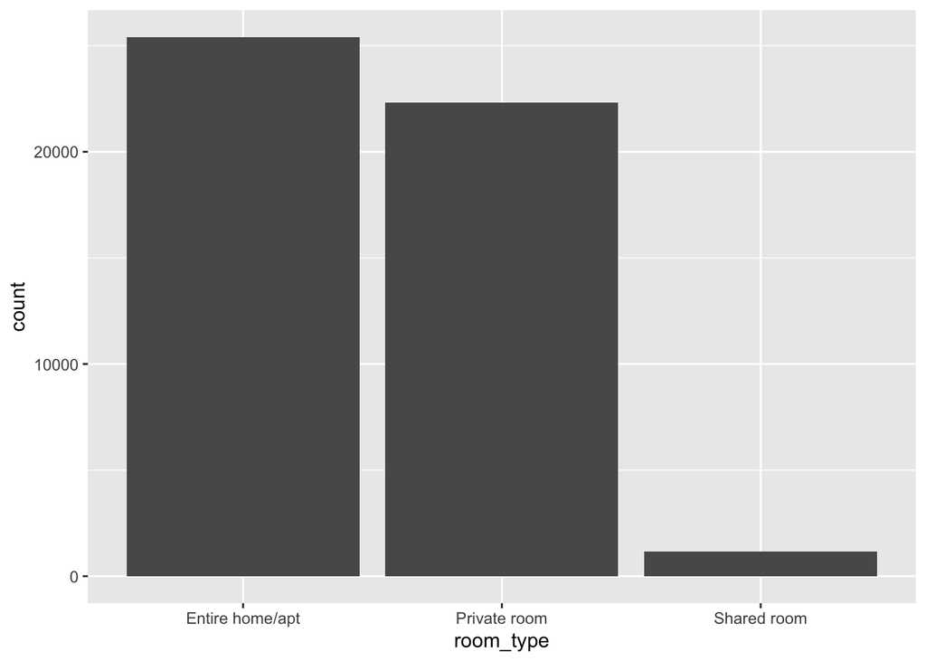

```r
ggplot(selected, aes(x=room_type)) +
  geom_bar(stat = "count") +
  labs(x = "room_type")
```

From the distribution graph,

nearly 52% prefer booking the entire place posted,

nearly 46% prefer booking a private room,

the rest 2% prefer booking a shared room.

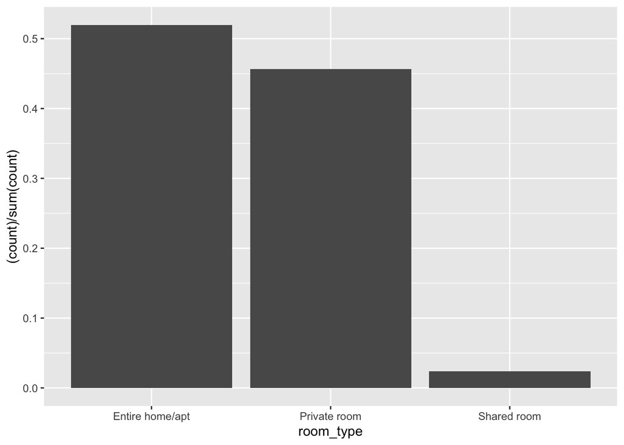

```r
ggplot(selected, aes(x=room_type)) +
  geom_bar(aes(y = (..count..)/sum(..count..))) +
  labs(x = "room_type")
```

Moreover, to see the areas with the highest preference in New York, neighborhood group distribution must be analyzed.

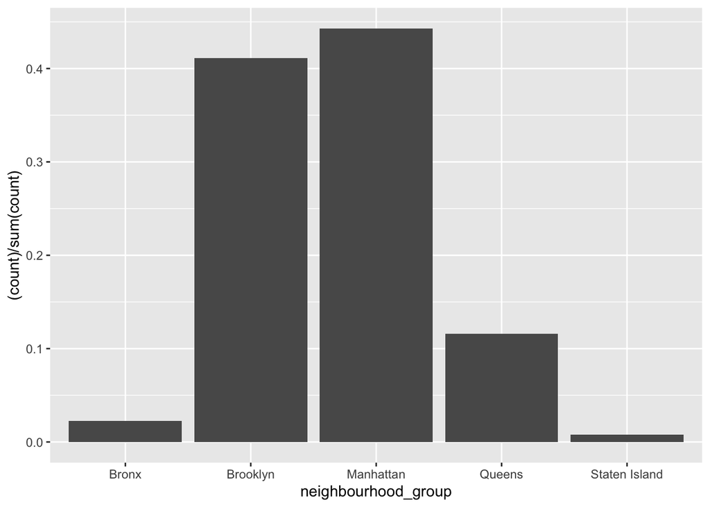

```r
ggplot(selected, aes(x=neighbourhood_group)) +
  geom_bar(aes(y = (..count..)/sum(..count..))) +
  labs(x = "neighbourhood_group")
```

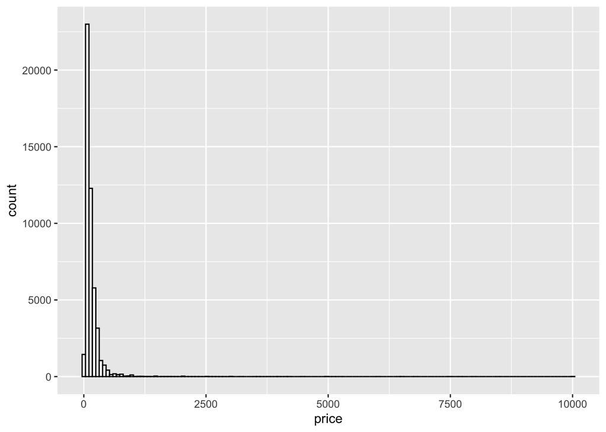

```r
ggplot(selected, aes(x=price)) +
  geom_histogram(color="black", fill="white", binwidth=70)
```

To check the price range and how many rentals were rented for a specific price, the price distribution should be visualized. Firstly, the statistics for the column, price, are calculated.

```r
c(min(data$price), max(data$price), mean(data$price), median(data$price))
```

```
## [1]     0.0000 10000.0000   152.7207   106.0000
```

From the calculation, it’s clearly seen that even though price has a large range, the median and the mean of the price are relatively low. To see the frequency of each price, ggplot is used to visualize. The limit for the x axis, price, is selected as 1000. By doing so, the plot becomes easily readable and outliers are removed. From the graph, the price frequency lies on the left-hand side. The Airbnb users primarily prefer cheaper rentals as the majority of the price frequency is shifted to the left side of the graph.

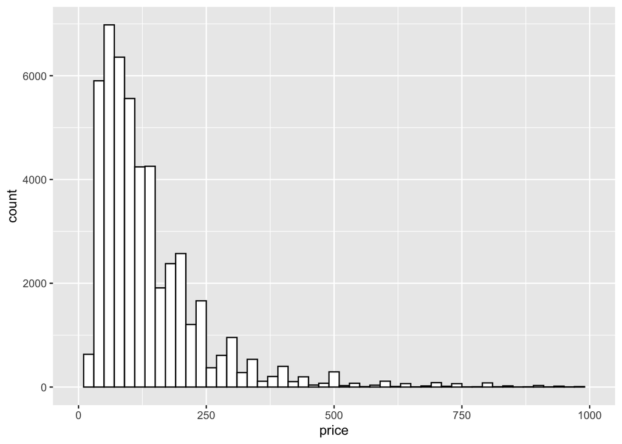

```r
ggplot(selected, aes(x=price)) +
  geom_histogram(color="black", fill="white", binwidth=20) +
  xlim(c(0,1000))
```

```r
aggregate(selected$price, list(selected$room_type), mean)
```

```
##           Group.1         x
## 1 Entire home/apt 211.79425
## 2    Private room  89.78097
## 3     Shared room  70.12759
```

The code below provides the neighborhoods mostly prefered by Airbnb users.

```r
tail(names(sort(table(selected$neighbourhood))), 10)
```

```
##  [1] "Midtown"            "Crown Heights"      "Upper East Side"
##  [4] "East Village"       "Hell's Kitchen"     "Upper West Side"
##  [7] "Bushwick"           "Harlem"             "Bedford-Stuyvesant"
## [10] "Williamsburg"
```

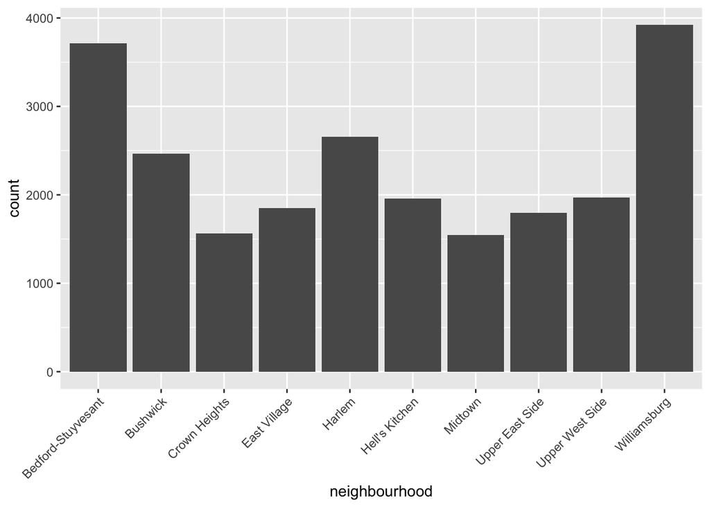

```r
z <- tail(names(sort(table(selected$neighbourhood))), 10)
ggplot(selected[selected$neighbourhood %in% z,], aes(x=neighbourhood)) +
  geom_bar(stat = "count") +
  labs(x = "neighbourhood") +
  theme(axis.text.x = element_text(angle = 45, hjust = 1))
```

Moreover, the code below shows the average price for each type of rental. From the results, Entire home or apartments have the highest price mean as expected, followed by private rooms and shared rooms, again, as expected.

```r
aggregate(selected$price, list(selected$room_type), mean)
```

```
##           Group.1         x
## 1 Entire home/apt 211.79425
## 2    Private room  89.78097
## 3     Shared room  70.12759
```

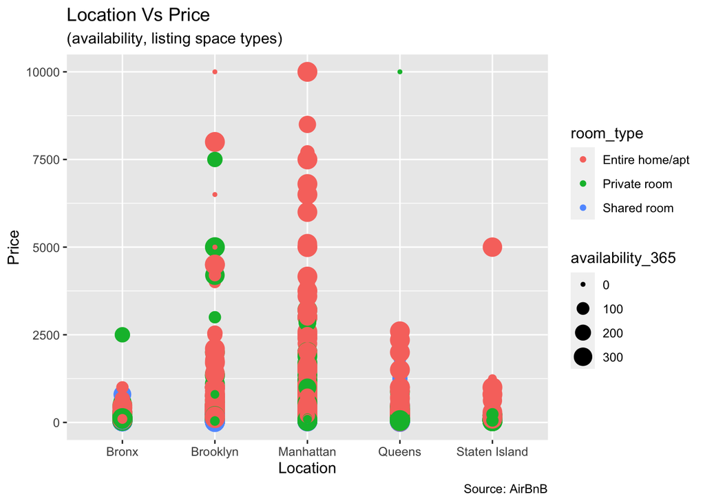

```r
ggplot(data, aes(x=neighbourhood_group, y=price)) +
  geom_point(aes(col=room_type, size=availability_365)) +
  ylim(c(0, 10000)) +
  labs(title="Location Vs Price",
       subtitle="(availability, listing space types)",
       x="Location",
       y="Price",
       caption = "Source: AirBnB")
```